# house_prices

Alex P.

December 30, 2016

## The Problem

A house is usually the most expensive purchase an individual makes in his or her lifetime. This is why it’s so critical that you are able to get a fair deal on a property - overpaying by $100,000 is a fatal mistake!

In this analysis, I build a regression model using data on houses in Ames, Iowa. The dataset has 79 explanatory variables usable to predict home selling prices. Home buyers may not be building regression models to evaluate their home purchases, but appraisers, real estate firms investment firms can use these techniques to evaluate fair property values.

## Basic Data Preprocessing

```r
setwd("/home/reztip/Desktop/kaggle/house_prices/source")
root = ".."
data.path  =  file.path(root, "input", "train.csv")
train.df = read.csv(data.path, header = TRUE)
```

```r
house.ids = select(train.df, Id)
house.prices = select(train.df, SalePrice)
# Drop the id from training
train.df = select(train.df, -Id)
```

## Analysis of Dataset Structure

How many variables do we have for training? How many houses does this dataset cover?

```r
# How many variables we have for training
length(names(train.df)) - 1
```

```
## [1] 79
```

```r
nrow(train.df)
```

```
## [1] 1460
```

How many of these data are numeric? At first glance, it looks to be about half. However, this dataset doesn’t look very “clean” - lots of these features are categorical which requires the generation of more binary features (one column for each value of a categorical variable). More on that later.

```r
colwise(is.numeric)(train.df) %>% data.frame %>%
  melt(id = "SalePrice") %>% select(variable, value)
```

```
##         variable value
## 1     MSSubClass  TRUE
## 2       MSZoning FALSE
## 3    LotFrontage  TRUE
## 4        LotArea  TRUE
## 5         Street FALSE
## 6          Alley FALSE
## 7       LotShape FALSE
## 8    LandContour FALSE
## 9      Utilities FALSE
## 10     LotConfig FALSE
## 11     LandSlope FALSE
## 12  Neighborhood FALSE
## 13    Condition1 FALSE
## 14    Condition2 FALSE
```

[output cut: 65 more lines]

```r
colwise(is.numeric)(train.df) %>% unlist %>% sum
```

```
## [1] 37
```

How about data quality - which variables are missing the most data?

```r
unlist(colwise(function(x) sum(is.na(x)))(train.df)) %>% sort(decreasing = T)
```

```
##        PoolQC   MiscFeature         Alley         Fence   FireplaceQu
##          1453          1406          1369          1179           690
##   LotFrontage    GarageType   GarageYrBlt  GarageFinish    GarageQual
##           259            81            81            81            81
##    GarageCond  BsmtExposure  BsmtFinType2      BsmtQual      BsmtCond
##            81            38            38            37            37
##  BsmtFinType1    MasVnrType    MasVnrArea    Electrical    MSSubClass
##            37             8             8             1             0
##      MSZoning       LotArea        Street      LotShape   LandContour
##             0             0             0             0             0
##     Utilities     LotConfig     LandSlope  Neighborhood    Condition1
##             0             0             0             0             0
##    Condition2      BldgType    HouseStyle   OverallQual   OverallCond
##             0             0             0             0             0
##     YearBuilt  YearRemodAdd     RoofStyle      RoofMatl   Exterior1st
##             0             0             0             0             0
##   Exterior2nd     ExterQual     ExterCond    Foundation    BsmtFinSF1
##             0             0             0             0             0
##    BsmtFinSF2     BsmtUnfSF   TotalBsmtSF       Heating     HeatingQC
##             0             0             0             0             0
##    CentralAir     X1stFlrSF     X2ndFlrSF  LowQualFinSF     GrLivArea
##             0             0             0             0             0
##  BsmtFullBath  BsmtHalfBath      FullBath      HalfBath  BedroomAbvGr
##             0             0             0             0             0
##  KitchenAbvGr   KitchenQual  TotRmsAbvGrd    Functional    Fireplaces
##             0             0             0             0             0
##    GarageCars    GarageArea    PavedDrive    WoodDeckSF   OpenPorchSF
##             0             0             0             0             0
## EnclosedPorch    X3SsnPorch   ScreenPorch      PoolArea       MiscVal
##             0             0             0             0             0
##        MoSold        YrSold      SaleType SaleCondition     SalePrice
##             0             0             0             0             0
```

We are missing the most data for POOLQC, MiscFeature, Alley and Fence - more than $2/3$ of the dataset. I drop these variables.

```r
train.df = select(train.df, -PoolQC, -MiscFeature, -Alley, -Fence)
```

## Dealing With Missing Values

I also do either median filling or mode filling for the other variables missing any data.

```r
nas.meaningful = c("FireplaceQu", "GarageType", "GarageYrBlt", "GarageFinish",
                   "GarageQual", "GarageCond", "BsmtExposure", "BsmtFinType2",
                   "BsmtQual", "BsmtCond", "BsmtFinType1")

nas.not.meaningful = c("LotFrontage", "MasVnrType", "MasVnrArea", "Electrical")
```

```r
for( var in nas.meaningful){
  fact.levels = levels(train.df[, var])
  mode.val = "Meaningful.NA"
  train.df[var] = factor(train.df[var],
                  levels = c(fact.levels, mode.val))
  train.df[is.na(train.df[var]), var] = mode.val
}
```

```r
for(var in nas.not.meaningful){
  if(! is.numeric(train.df[, var])){
    fact.levels = levels(train.df[, var])
    mode.val = sort(table(train.df[var]), decreasing = T)[[1]]
    train.df[var] = factor(train.df[var],
                  levels = c(fact.levels, mode.val))
  }
  else {
    mode.val = median(train.df[,var], na.rm = T)
  }
    train.df[is.na(train.df[var]), var] = mode.val
}
```

This is all well and good, but there is a lot of information still here that requires manual scrubbing. Take, for example, the *MSSubClass* variable. It is recorded as a numeric variable, but really represents categorical information.

I “fix” dataset problems in the code below.

```r
train.df$MSSubClass = as.factor(train.df$MSSubClass)
train.df$OverallQual = as.factor(train.df$OverallQual)
train.df$OverallCond = as.factor(train.df$OverallCond)
train.df = na.omit(train.df)
```

Now we can being some analysis.

# Data Visualization

First, how are home prices distributed?

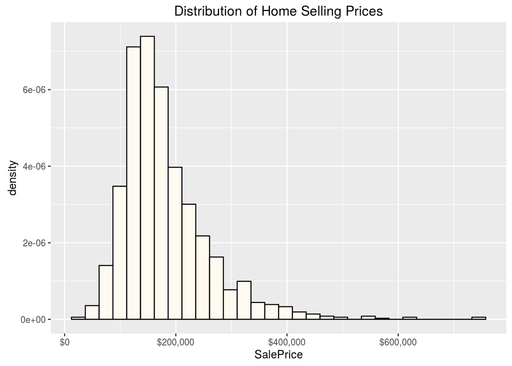

```r
ggplot(train.df,
       aes(SalePrice, y = ..density.., fill = I("floralwhite"))) +
  geom_histogram(bins = 30, color = 'black') +
  scale_x_continuous(labels = scales::dollar_format()) +
  labs(title = "Distribution of Home Selling Prices")
```

There is a clear trend here, the dataset looks like a log-powernormal distribution. There is a clear mode at just below $200,000, with a short left tail and a very long right tail. There is a pretty high standard deviation to the dataset - about $79,000!

There appears to be a “power law” at play, indicating that the logarithm of home price will probably look more gaussian.

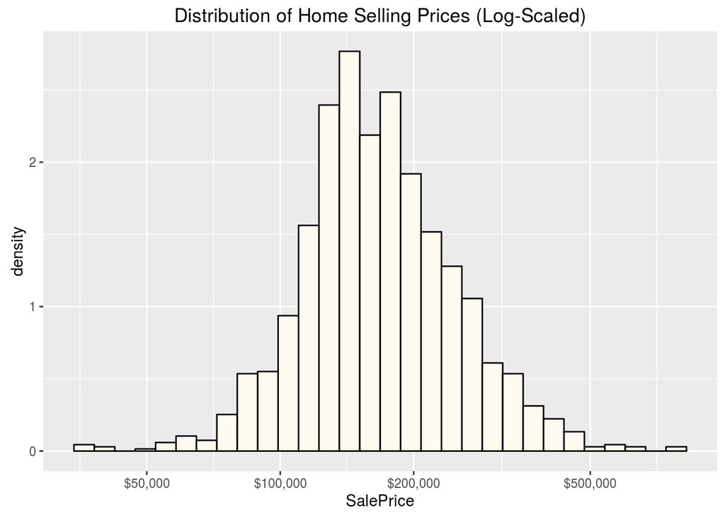

```r
ggplot(train.df,
       aes(SalePrice, y = ..density.., fill = I("floralwhite"))) +
  geom_histogram(bins = 30, color = 'black') +
  scale_x_log10(labels = scales::dollar_format(),
                breaks = c(.5E5, 1E5, 2E5, 5E5)) +
  labs(title = "Distribution of Home Selling Prices (Log-Scaled)")
```